# Exploration of MPG Dataset

Shailesh Kumar

This notebook explores the mpg dataset available in the ggplot2 package. The goals of this notebook are:

- General understanding of mpg dataset
- Learning features of ggplot2 package

```r
require(ggplot2)
```

This dataset provides fuel economy data from 1999 and 2008 for 38 popular models of cars. The dataset is shipped with *ggplot2* package.

| Variable | Type | Description | Details |
| --- | --- | --- | --- |
| manufacturer | string | car manufacturer | 15 manufacturers |
| model | string | model name | 38 models |
| displ | numeric | engine displacement in liters | 1.6 - 7.0, median: 3.3 |
| year | integer | year of manufacturing | 1999, 2008 |
| cyl |  | number of cylinders | 4, 5, 6, 8 |
| trans | string | type of transmission | automatic, manual (many sub types) |
| drv | string | drive type | f, r, 4, f=front wheel, r=rear wheel, 4=4 wheel |
| cty | integer | city mileage | miles per gallon |
| hwy | integer | highway mileage | miles per gallon |
| fl | string | fuel type | 5 fuel types (diesel, petrol, electric, etc.) |
| class | string | vehicle class | 7 types (compact, SUV, minivan etc.) |

Description of mpg dataset

```r
str(mpg)
```

```
## Classes 'tbl_df', 'tbl' and 'data.frame':    234 obs. of  11 variables:
##  $ manufacturer: chr  "audi" "audi" "audi" "audi" ...
##  $ model       : chr  "a4" "a4" "a4" "a4" ...
##  $ displ       : num  1.8 1.8 2 2 2.8 2.8 3.1 1.8 1.8 2 ...
##  $ year        : int  1999 1999 2008 2008 1999 1999 2008 1999 1999 2008 ...
##  $ cyl         : int  4 4 4 4 6 6 6 4 4 4 ...
##  $ trans       : chr  "auto(l5)" "manual(m5)" "manual(m6)" "auto(av)" ...
##  $ drv         : chr  "f" "f" "f" "f" ...
##  $ cty         : int  18 21 20 21 16 18 18 18 16 20 ...
##  $ hwy         : int  29 29 31 30 26 26 27 26 25 28 ...
##  $ fl          : chr  "p" "p" "p" "p" ...
##  $ class       : chr  "compact" "compact" "compact" "compact" ...
```

Number of rows or observations or records

```r
nrow(mpg)
```

```
## [1] 234
```

Number of columns or variables

```r
ncol(mpg)
```

```
## [1] 11
```

Names of columns

```r
colnames(mpg)
```

```
##  [1] "manufacturer" "model"        "displ"        "year"         "cyl"
##  [6] "trans"        "drv"          "cty"          "hwy"          "fl"
## [11] "class"
```

### Manufacturers

```r
table(mpg$manufacturer)
```

```
##
##       audi  chevrolet      dodge       ford      honda    hyundai       jeep
##         18         19         37         25          9         14          8
## land rover    lincoln    mercury     nissan    pontiac     subaru     toyota
##          4          3          4         13          5         14         34
## volkswagen
##         27
```

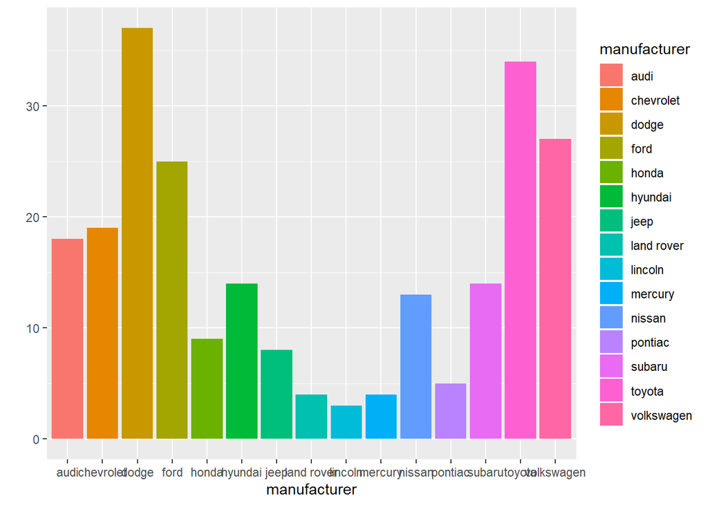

```r
qplot(manufacturer, data=mpg, geom="bar", fill=manufacturer)
```

### Year of manufacturing

```r
table(mpg$year)
```

```
##
## 1999 2008
##  117  117
```

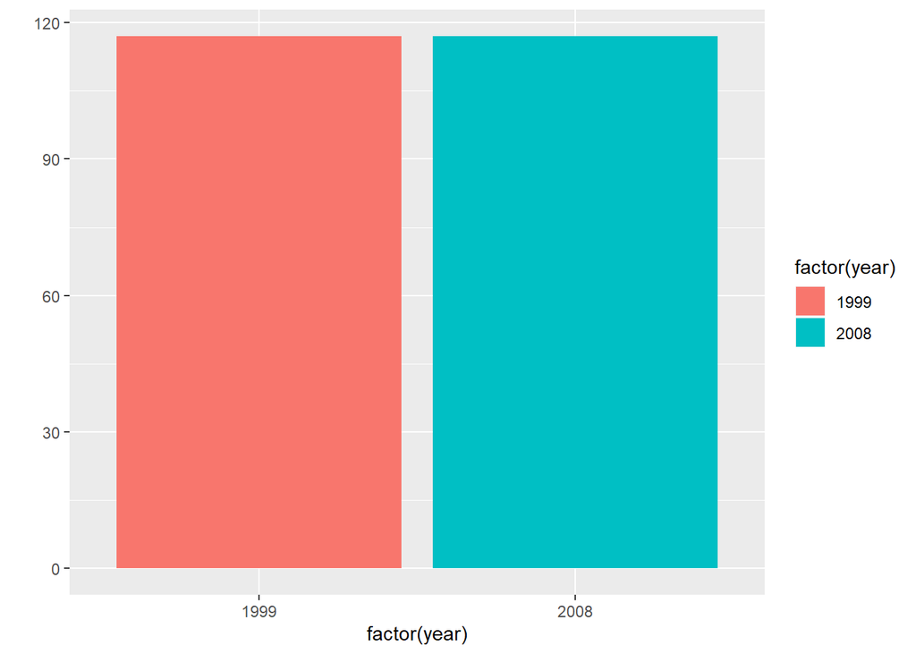

```r
qplot(factor(year), data=mpg, geom="bar", fill=factor(year))
```

### Displacement

```r
summary(mpg$displ)
```

```
##    Min. 1st Qu.  Median    Mean 3rd Qu.    Max.
##   1.600   2.400   3.300   3.472   4.600   7.000
```

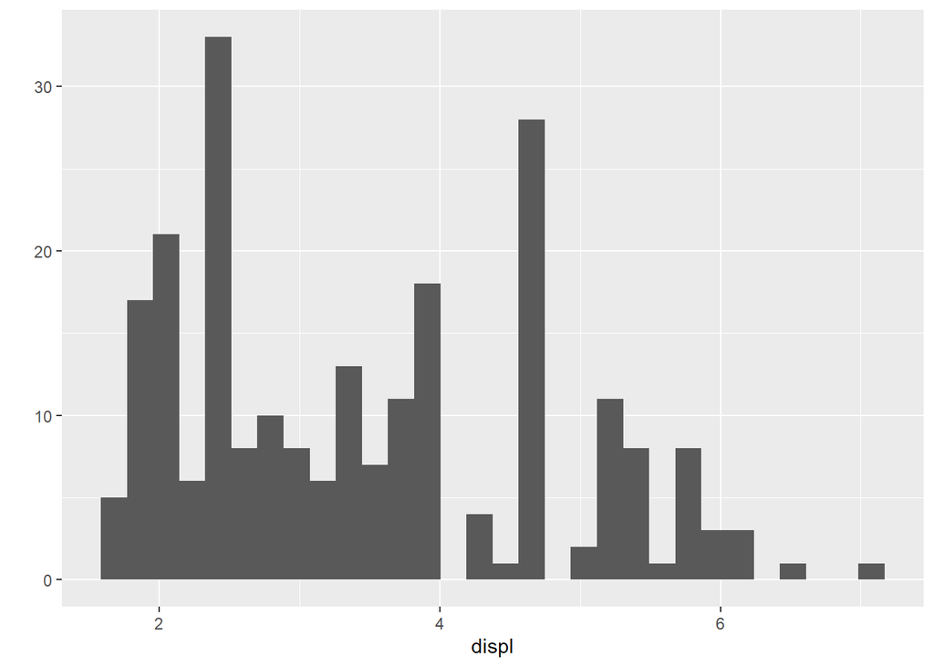

```r
qplot(displ, data=mpg, geom="histogram", bins=30)
```

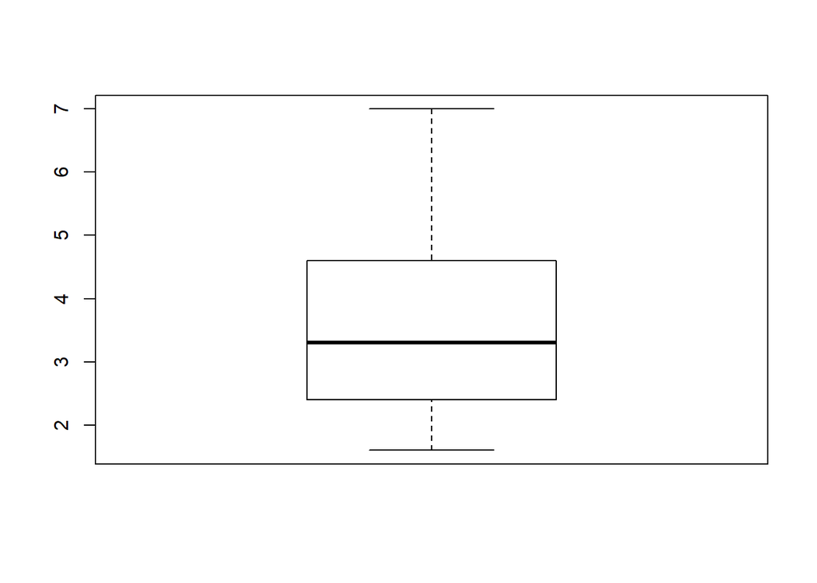

```r
boxplot(mpg$displ)
```

### Cylinders

```r
table(mpg$cyl)
```

```
##
##  4  5  6  8
## 81  4 79 70
```

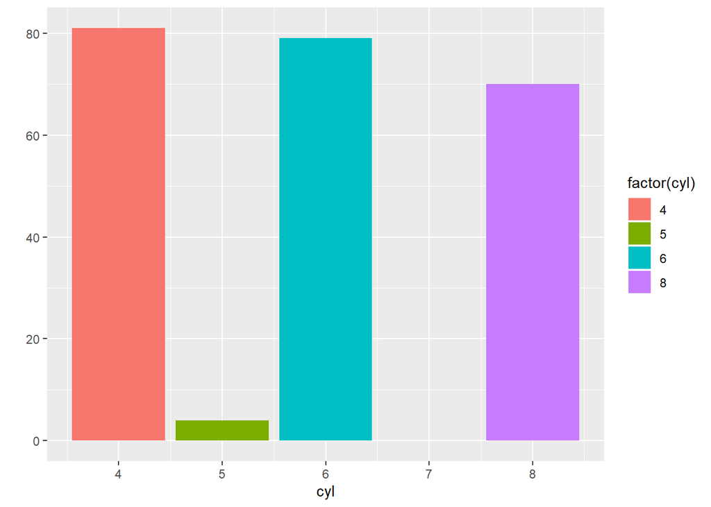

```r
qplot(cyl, data=mpg, geom="bar", fill=factor(cyl))
```

### Transmission types

```r
table(mpg$trans)
```

```
##
##   auto(av)   auto(l3)   auto(l4)   auto(l5)   auto(l6)   auto(s4)   auto(s5)
##          5          2         83         39          6          3          3
##   auto(s6) manual(m5) manual(m6)
##         16         58         19
```

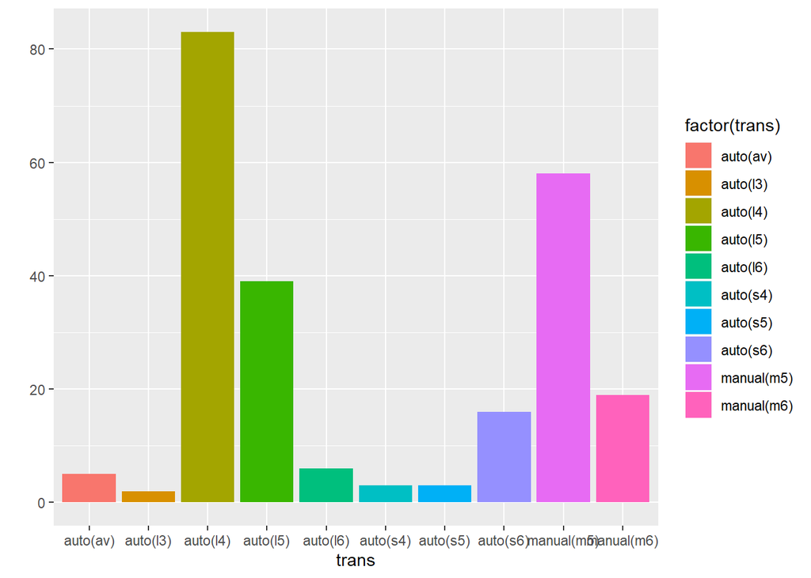

```r
qplot(trans, data=mpg, geom="bar", fill=factor(trans))
```

### Wheel drive types

```r
table(mpg$drv)
```

```
##
##   4   f   r
## 103 106  25
```

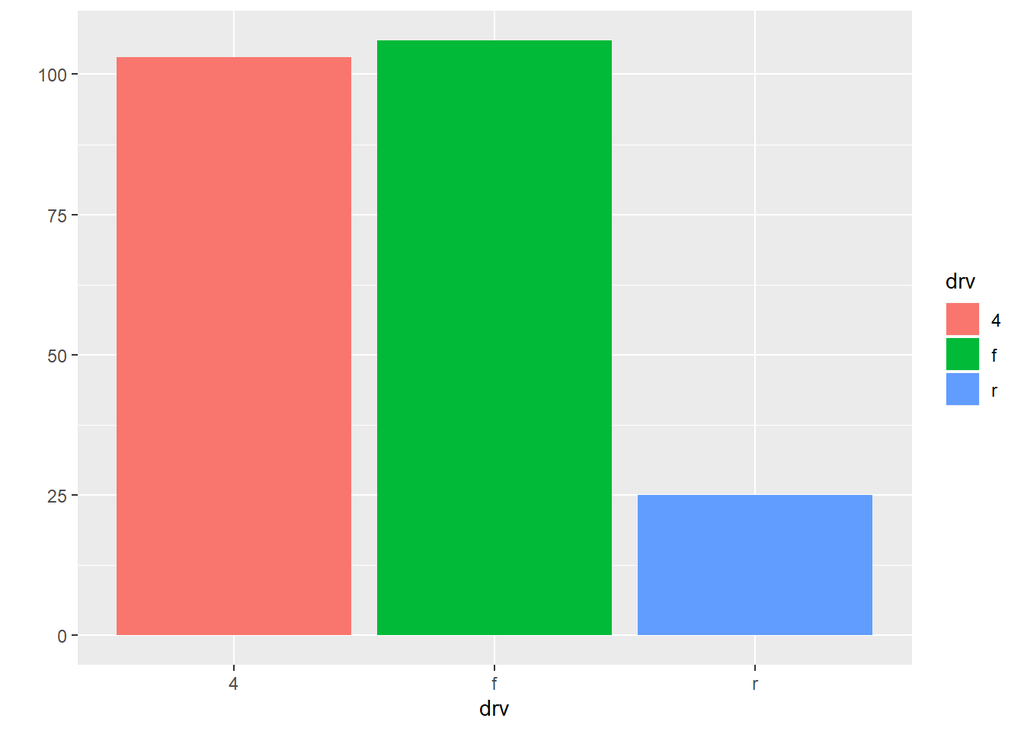

```r
qplot(drv, data=mpg, geom="bar", fill=drv)
```

### Mileage in city

```r
summary(mpg$cty)
```

```
##    Min. 1st Qu.  Median    Mean 3rd Qu.    Max.
##    9.00   14.00   17.00   16.86   19.00   35.00
```

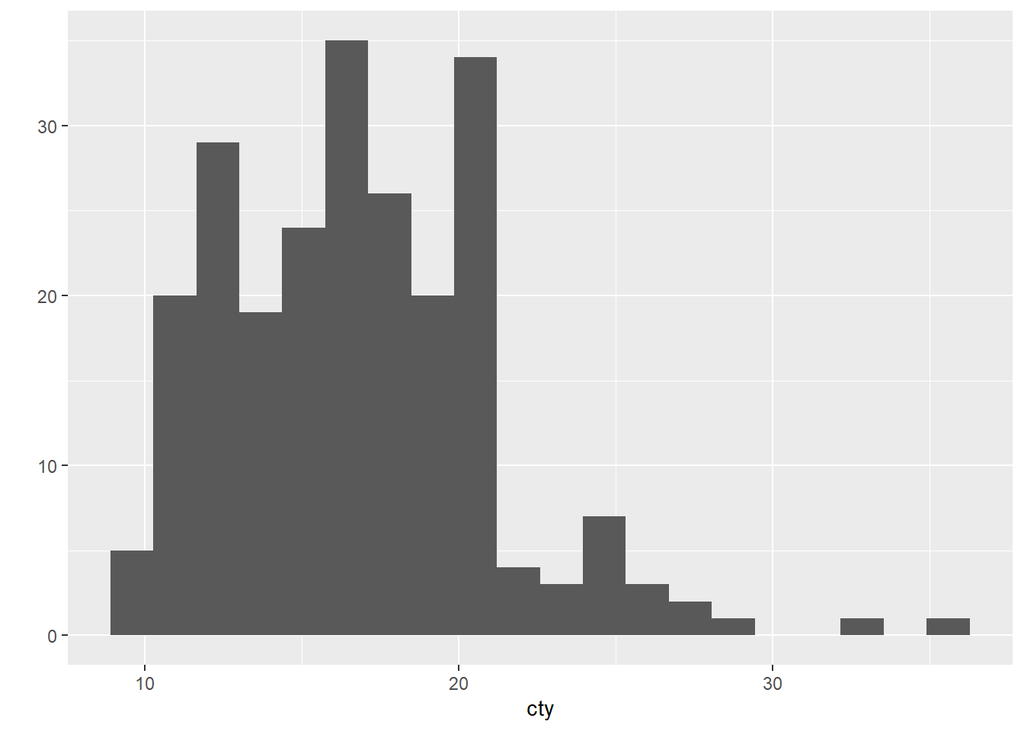

```r
qplot(cty, data=mpg, geom="histogram", bins=20)
```

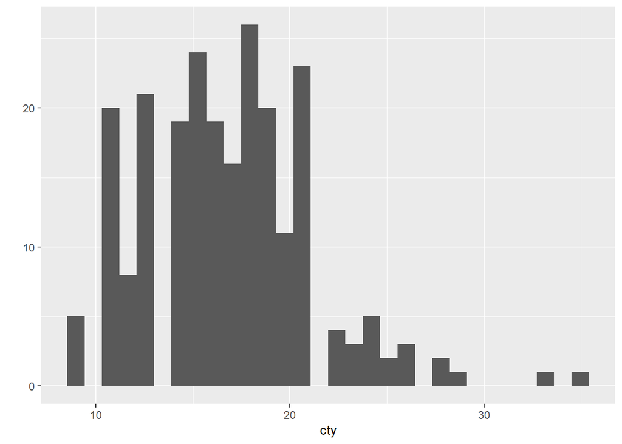

```r
qplot(cty, data=mpg, geom="histogram", bins=30)
```

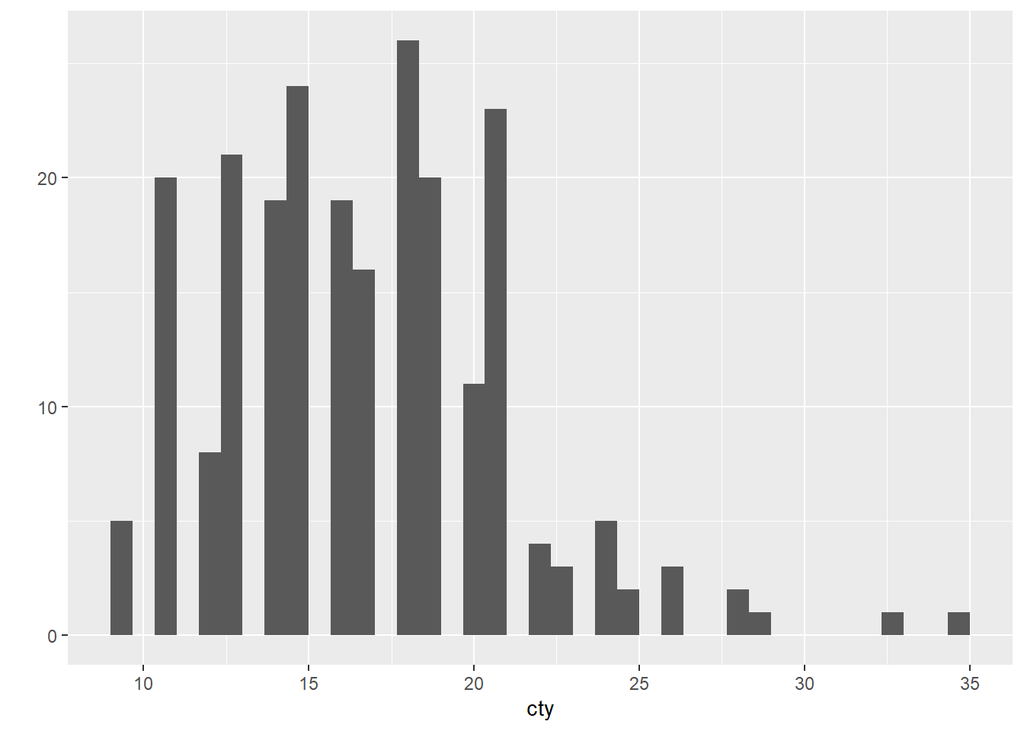

```r
qplot(cty, data=mpg, geom="histogram", bins=40)
```

### Mileage in highways

```r
summary(mpg$hwy)
```

```
##    Min. 1st Qu.  Median    Mean 3rd Qu.    Max.
##   12.00   18.00   24.00   23.44   27.00   44.00
```

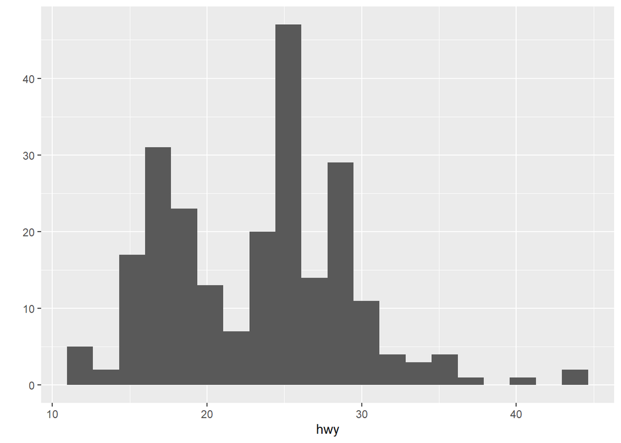

```r
qplot(hwy, data=mpg, geom="histogram", bins=20)
```

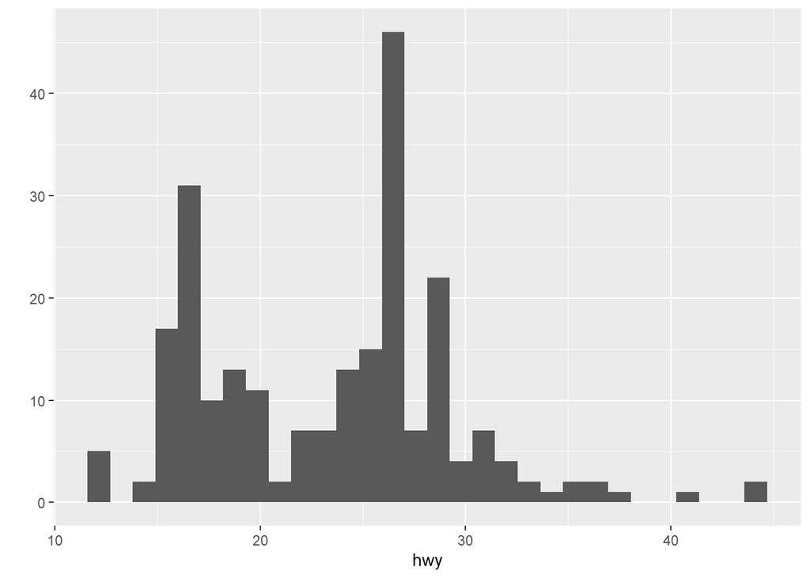

```r
qplot(hwy, data=mpg, geom="histogram", bins=30)
```

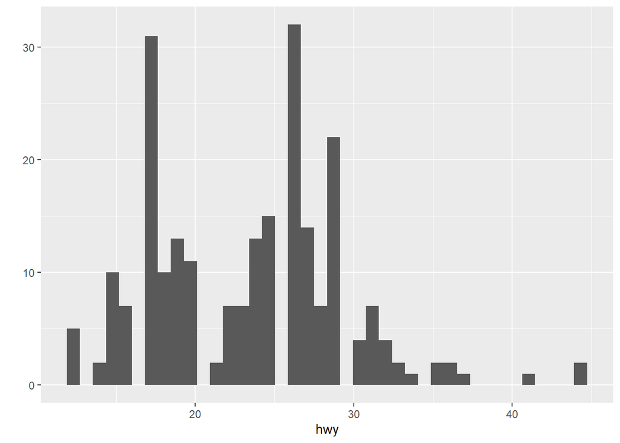

```r
qplot(hwy, data=mpg, geom="histogram", bins=40)
```

### Fuel types

```r
table(mpg$fl)
```

```
##
##   c   d   e   p   r
##   1   5   8  52 168
```

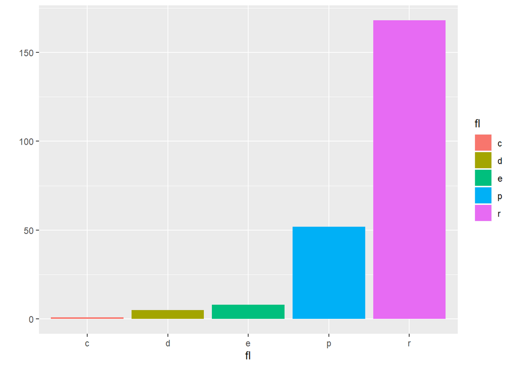

```r
qplot(fl, data=mpg, geom="bar", fill=fl)
```

### Vehicle Class

```r
table(mpg$class)
```

```
##
##    2seater    compact    midsize    minivan     pickup subcompact        suv
##          5         47         41         11         33         35         62
```

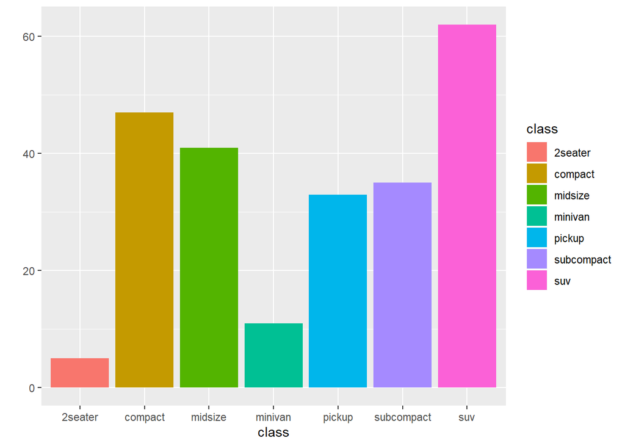

```r
qplot(class, data=mpg, geom="bar", fill=class)
```

### Displacement vs highway efficiency

```r
ggplot(data = mpg) +
  geom_point(mapping = aes(x = displ, y = hwy), color='blue')
```

[output not shown]

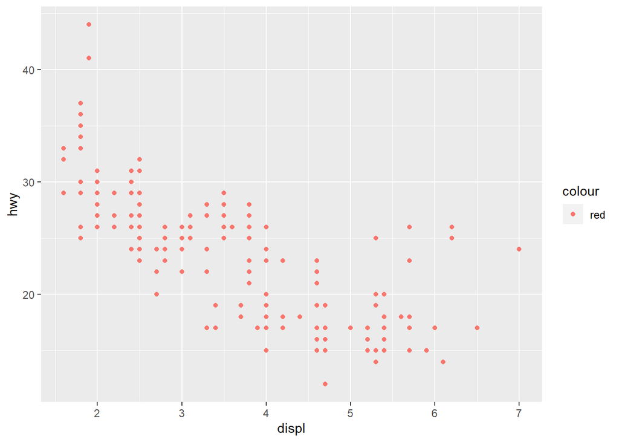

```r
qplot(displ, hwy, data=mpg, geom="point", color='red')
```

Looking at this data separately for each class

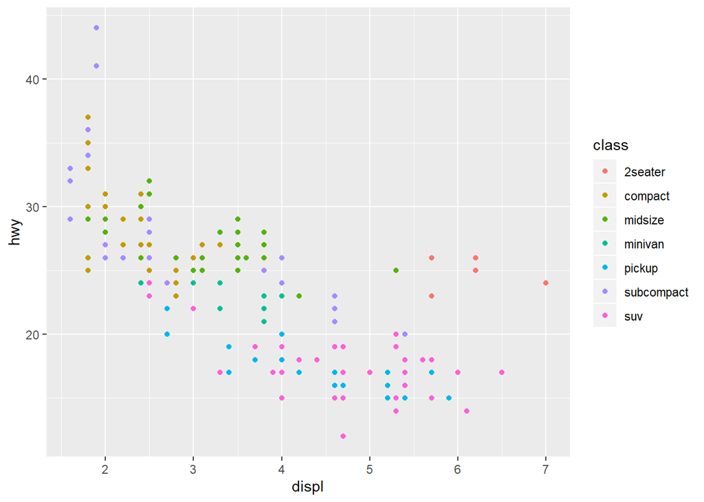

```r
qplot(displ, hwy, data=mpg, geom="point", color=class)
```

Fixing the color for all points

```r
qplot(displ, hwy, data=mpg, geom="point", color=I("blue"))
```

[output not shown]

The same graphic through ggplot

```r
ggplot(data=mpg) + geom_point(mapping = aes(x = displ, y = hwy), color = "blue")
```

[output not shown]

Separate graphs for each vehicle class:

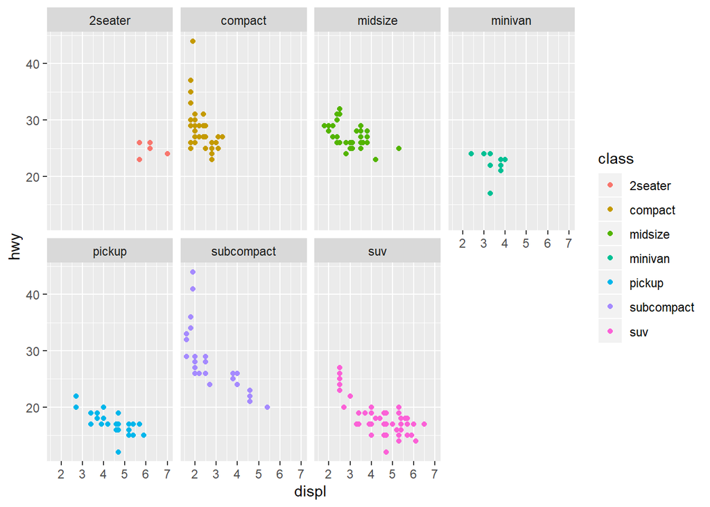

```r
ggplot(data = mpg) +
  geom_point(mapping = aes(x = displ, y = hwy, color=class)) +
  facet_wrap(~ class, nrow = 2)
```

Creating facets on the basis of two variables : number of cylinders and type of drive

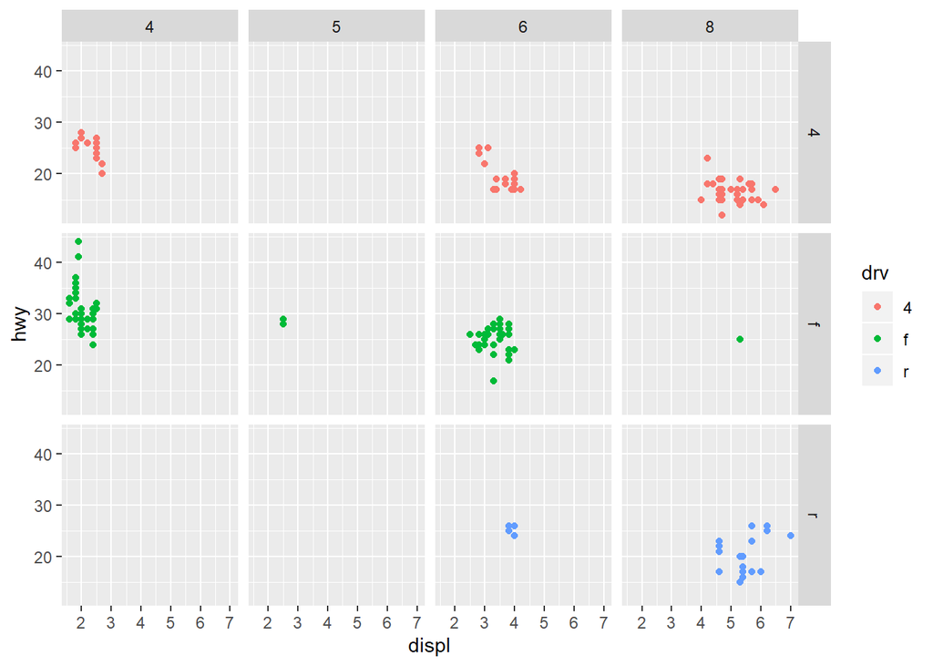

```r
ggplot(data = mpg) +
  geom_point(mapping = aes(x = displ, y = hwy, color=drv)) +
  facet_grid(drv ~ cyl)
```

There are no cars for some combinations of drive and cylinders.